# Lab 1 Introduction to Python

```python
import numpy as np
import matplotlib.pyplot as plt

def output(ans, goal):
   print("\t",goal, "=>", ans)
```

## P1.1

Read chapter 1 in the python book, performing all the prescribed tasks.

> I have been developing in Python for about 3 years. I felt pretty good about the book, and have chosen not to do the problems because of their trivial nature.

## P1.2

Read sections 3.1(integers),3.2(floats), and 4.2(importing libraries) in the python book, performing all example calculations. Then performthe following calculations:

##### P1.2 (a)

\begin{align} 5cos^2(23) + e^{10} \end{align}

```python
goal = "5*cos2(23deg) + e^10"
ans = 5.0 * np.cos(np.radians(23.0))**2 + np.e**10
output(ans, goal)
```

```
	 5*cos2(23deg) + e^10 => 22030.70244073285
```

##### P1.2 (b)

\begin{align} 5\sqrt{50} * 67^{2/3} \end{align}

```python
goal = "5 * sqrt(50) * 67^(2/3)"
ans = 5.0 * np.sqrt(50.0) * 67.0**(2/3.0)
output(ans, goal)
```

```
	 5 * sqrt(50) * 67^(2/3) => 583.227788614642
```

##### P1.2 (c)

\begin{align} 5cosh(20) + 8sinh(9) \end{align}

```python
goal = "5*cosh(20) + 8*sinh(9)"
ans = 5.0*np.cosh(20.0) + 8.0*np.sinh(9.0)
output(ans, goal)
```

```
	 5*cosh(20) + 8*sinh(9) => 1212945400.8596923
```

## P1.3

Read section 3.5(lists) and 4.1(native functions) in the python book, performing all of the example calculations. Then perform the following calculations:

##### P1.3 (a)

Sum of first 10 primes

```python
goal = "Sum of first 10 primes"
ans = [2, 3, 5, 7, 11, 13, 17, 19, 23, 29]
output(sum(ans), goal)
```

```
	 Sum of first 10 primes => 129
```

##### P1.3 (b)

Sum of first 11 primes

```python
goal = "Sum of first 11 primes"
ans.append(31)
output(sum(ans), goal)
```

```
	 Sum of first 11 primes => 160
```

##### P1.3 (c)

3 thru 54 by threes

```python
goal = "3 thru 54 by threes"
ans = list(range(3, 55, 3))
output(ans, goal)
```

```
	 3 thru 54 by threes => [3, 6, 9, 12, 15, 18, 21, 24, 27, 30, 33, 36, 39, 42, 45, 48, 51, 54]
```

##### P1.3 (d)

Sum of the above numbers

```python
goal = "Sum of those ^^^ numbers"
output(sum(ans), goal)
```

```
	 Sum of those ^^^ numbers => 513
```

## P1.4

Read section chapter 6(loops) in the python book, performing all example calculations. Then perform the following:

##### P1.4 (a)

```python
goal = "Look for multiples of 5"
ans = "Below 101:"
output(ans, goal)
for i in range(2, 102, 2):
   if i % 5 == 0:
      print("\t\tFiver:", i)
```

```
	 Look for multiples of 5 => Below 101:
		Fiver: 10
		Fiver: 20
		Fiver: 30
		Fiver: 40
		Fiver: 50
		Fiver: 60
		Fiver: 70
		Fiver: 80
		Fiver: 90
		Fiver: 100
```

##### P1.4 (b)

Find numerically the sum of `n((3/4)^n)` where `n -> 1:1000`

```python
goal = "Find numerically the sum of n((3/4)^n) where n -> 1:1000"
ans = sum(list([n*((3/4.0)**n) for n in range(1,1001)]))
output(ans, goal)
```

```
	 Find numerically the sum of n((3/4)^n) where n -> 1:1000 => 12.000000000000005
```

## P1.5

Read section chapter 6(loops) in the python book, performing all example calculations. Then perform the following:

```python
# P1.5 (a)
def some_function(a):
   # P1.5 (b)
   tmp = range(4, a, 3)
   # P1.5 (c)
   b = sum(tmp)
   # P1.5 (d)
   return np.sqrt(b)
```

```python
# P1.5 (e)
output(some_function(7), "Test our function with a as 7")
output(some_function(15), "Test our function with a as 15")
output(some_function(25), "Test our function with a as 25")
output(some_function(1234), "Test our function with a as 1234")
output(some_function(54399), "Test our function with a as 54399")
```

```
	 Test our function with a as 7 => 2.0
	 Test our function with a as 15 => 5.830951894845301
	 Test our function with a as 25 => 9.539392014169456
	 Test our function with a as 1234 => 503.1649828833481
	 Test our function with a as 54399 => 22208.094605346043
```

## P1.6

Read section chapter 6(loops) in the python book, performing all example calculations. Then performthe following:

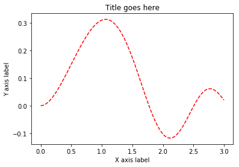

```python
# P1.6 (a)
x = np.linspace(0, 3, 100)
y = np.sin(x**2) * np.e**(-x)

# P1.6 (b)
plt.plot(x, y, 'r--')

# P1.6 (c)
plt.xlabel('X axis label')
plt.ylabel('Y axis label')

# P1.6 (d)
plt.title('Title goes here')

# P1.6 (e) No need to do this in a Jupyter Notebook
# filename = 'lab1_P1.6e.png'
# plt.savefig(filename)
# output(filename,"Plot found in")

# we can run this instead P1.6 (e)
plt.show()
```